# Genotype imputation

Pubh 8446

3/4/2020

# Genotype imputation

- Hidden Markov Model (HMM)
  - observed: genotyped SNPs
  - hidden states: (phased) haplotypes from reference panel (HapMap, 1K genome projects)
  - Refs
    - Howie, B., Fuchsberger, C., Stephens, M., Marchini, J., Abecasis, G.R., 2012. Fast and accurate genotype imputation in genome-wide association studies through pre-phasing. Nat. Genet. 44, 955–959.
    - Li, Y., Willer, C.J., Ding, J., Scheet, P., Abecasis, G.R., 2010. MaCH: using sequence and genotype data to estimate haplotypes and unobserved genotypes. Genetic Epidemiology 34, 816–834.
    - B. N. Howie, P. Donnelly, and J. Marchini (2009) A flexible and accurate genotype imputation method for the next generation of genome-wide association studies. PLoS Genetics 5(6): e1000529.
    - B L Browning and S R Browning (2009) A unified approach to genotype imputation and haplotype phase inference for large data sets of trios and unrelated individuals. Am J Hum Genet 84:210-223.
    - Li N, Stephens M (2003) Modeling linkage disequilibrium and identifying recombination hotspots using single-nucleotide polymorphism data. Genetics 165: 2213–2233.
    - Browning, B.L., Browning, S.R., 2016. Genotype Imputation with Millions of Reference Samples. The American Journal of Human Genetics 98, 116–126.
- Typical imputation scenario (from IMPUTE2 web)

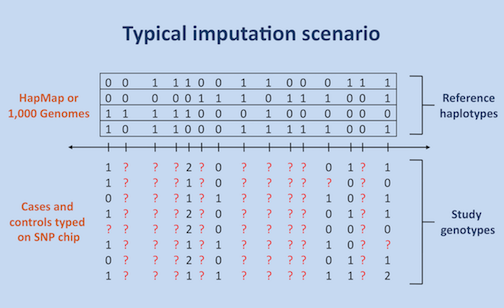

# HMM

- Some technical details on imputation HMM
  - describe sampled haplotypes as a mosaic of a set of reference haplotypes
  - (hidden) state $S=(x,y)$: 1st chr uses haplotype x and the 2nd chr uses y.
    - in total $H$ haplotypes
  - transition prob
    - transition probability between two mosaic states and reflect the likelihood of historical recombination events in the interval between two loci.
    - Given two states $S_j=(x_j,y_j), j=1,2$ (at two loci)
    - Given the crossover parameter $\theta_j$.
    - Model $\Pr(S_2|S_1)$ as
      - $\theta_2^2/H^2$, if $x_2\neq x_1$ and $y_2\neq y_1$ (# (H-1)^2 )
      - $\theta_2^2/H^2+(1-\theta_2)\theta_2/H$, if $x_2\neq x_1$ or $y_2\neq y_1$ (# 2(H-1) )
      - $\theta_2^2/H^2+2(1-\theta_2)\theta_2/H+(1-\theta_2)^2$ if $x_2=x_1$ and $y_2= y_1$ (# 1)
    - $\theta_j$ reflects a combination of population recombination rates and the relatedness between the haplotypes being resolved and the true underlying haplotypes (important to choose the right reference samples).
  - emission prob
    - probability of observed genotypes at each position conditional on the underlying mosaic state and reflect the combined effects of gene conversion, mutation, and genotyping error.
    - $T(S_j)=T(x_j)+T(y_j)$ denotes the implied genotype.
    - $G_j$ is the observed genotype.
    - Given error parameter $\epsilon_j$.
    - Model $\Pr(G_j|S_j)$ as
      - $(1-\epsilon_j)^2+\epsilon_j^2$, if $T(S_j)=G_j$ and $G_j$ is heterozygote.
      - $2(1-\epsilon_j)\epsilon_j$, if $T(S_j)\neq G_j$ and $G_j$ is heterozygote.
      - $(1-\epsilon_j)^2$, if $T(S_j)=G_j$ and $G_j$ is homozygote.
      - $(1-\epsilon_j)\epsilon_j$, if $T(S_j)$ is heterozygote and $G_j$ is homozygote.
      - $\epsilon_j^2$, if $T(S_j)$ and $G_j$ are opposite homozygotes.
    - $\epsilon_j$ reflects a combination of genotyping error, gene conversion events, recurrent mutation and, when genotype data from multiple platforms or laboratories is used, assay inconsistencies between different platforms
- Genotype imputation procedure
  - HMM parameter estimation: iterative procedures (EM algorithm)
  - at each iteration (given the current estimated parameters)
    - sampling all hidden states from $\Pr(S|G)\propto\Pr(G,S)=\Pr(S_1)\prod_j\Pr(S_j|S_{j-1})\prod_j\Pr(G_j|S_j)$
  - aggregate all samplings across all iterations
    - relative props of alleles (genotype dist): calculate the imputed genotype scores
  - Equivalent to (in an EM framework)
    - decoding each hidden state marginally/separately $\Pr(S_j|G)$
    - replacing theoretical conditional expectation (in the EM iteration) with random Monte Carlo sampling (in the same spirit as MCEM): $E[\log\Pr(G,S)|G] \approx \sum_b \log\Pr(G,S_b)$ where $S_b\sim \Pr(S|G)$ (using current parameter estimates).
    - conditional maximization of $\theta_j$ and $\epsilon_j$: straightforward one-parameter optimization problem at each locus separately.
- Imputation quality
  - given $n$ individuals to be imputed.
  - each individual has imputed dosage score $g_j$ (estimated from proportion of sampled genotypes in HMM)
  - $R^2 = \frac{Var(g_j)}{2\mu(1-\mu)}$, where $\mu=\sum_jg_j/n/2$.
    - $\mu$ is the estimated MAF
    - under ideal imputation, $g_j\sim Binom(2,\mu)$, and $Var(g_j)=2\mu(1-\mu)$.
    - The smaller the $R^2$, the less certain of imputation.
    - Common variant (MAF>0.05): $R^2\geq 0.3$.

# Test association of imputed SNPs

- Imputation output: $(p_0,p_1,p_2)$ the probability of three genotype scores (0,1,2).
- Called genotypes share similar property of uncertainty (measurement error) as imputed SNPs
  - highthroughput chips interogate millions of SNPs
  - intensity values for three genotypes -> called genotypes
  - uncertainty associated with called genotypes (estimated parameters).
- Some simple approach
  - “best-guess” genotype: $G=\arg\max_ip_i$
    - generally under-powered
    - work well if $\max_i p_i$ is close to 1 (for most called genotypes)
  - dosage genotype: treat $G=p_1+2p_2$ as the genotype score (assume additive genetic model)
    - generally better than “best-guess” and commonly used
- Refs
  - Acar, E.F., Sun, L., 2013. A Generalized Kruskal–Wallis Test Incorporating Group Uncertainty with Application to Genetic Association Studies. Biometrics 69, 427–435.
  - Wu, B., Guan, W., 2014. on the generalized Kruskal–Wallis test for genetic association studies incorporating group uncertainty. Biometrics, 71(2), 556-557.
  - Zheng, J., Li, Y., Abecasis, G.R., Scheet, P., 2011. A comparison of approaches to account for uncertainty in analysis of imputed genotypes. Genetic Epidemiology 35, 102–110.
  - Hu, Y. j., Lin, D. y., 2010. Analysis of untyped SNPs: maximum likelihood and imputation methods. Genetic Epidemiology 34, 803–815.
  - Huang KC, Sun W, Wu Y, Chen M, Mohlke KL, Lange LA, Li Y. 2014. Association studies with imputed variants using expectation-maximization likelihood-ratio tests. PLoS One 9(11):e110679.
  - Li Y, Byrnes AE, Li M. 2010. To identify associations with rare variants, just WHaIT: Weighted Haplotype and Imputation-based Tests. American Journal of Human Genetics 87: 728-735.
  - Yan S, Yuan S, Xu Z, Zhang B, Zhang B, Kang G, Byrnes A, Li Y. 2015. Likelihood-based complex trait association testing for arbitrary depth sequencing data. Bioinformatics. 31(18):2955-62.

# Finite mixture modeling

- A general framework for association test of imputed SNPs using finite mixture model
  - Given outcome $Y$, covariate $X$, genotype $G$
  - Outcome model: $f_y(Y|X,G)$, e.g.,
    - continuous trait: $Y \sim N(X\alpha+G\beta,\sigma^2)$
    - binary trait: $Y\sim Bern(\theta)$ with $logit(\theta)=X\alpha+G\beta$
    - Exponential family dist with GLM
  - Genotype imputation model
    - $\Pr(G=g)=p_g, g=0,1,2$
    - treat $p_g$ as known constants
  - Marginal model for $Y$
    - $\Pr(Y|X) = \sum_{g=0}^2 p_gf_y(Y|X,G=g)$
    - a finite mixture model
    - Wald test
      - numerical estimation of $\beta$
      - asymptotic covariance estimation using Fisher information matrix
      - generally computing intensive
    - Score test under a GLM
      - outcome is linked to covariates through $\eta = x\alpha + g\beta$
      - log likelihood $\ell = \log(f)$ with $f=\sum_{g=0}^2 p_gf_y(y|x,g)$
      - null model ($H_0:\beta=0$) reduces to $f_0=f_y(Y|X)$ with $\eta=x\alpha$
      - score function $U=\frac{\partial\ell}{\partial\beta} = f^{-1}[\sum_g p_g \frac{\partial f_y(y|x,g)}{\partial\eta} g]$
      - under null $U=f_0^{-1}\frac{\partial f_0}{\partial\eta} [\sum_g gp_g]$.
      - this is the same score as in the model $\Pr(Y|X,G)=f_d(Y|X,G)$ with $\eta=x\alpha + G\beta$ where $G=p_1+2p_2$ is the imputed dosage.
    - So
      - for Score test, using the imputation dosage in the orginal model is equivalent to the finite mixture model (gold standard model)
      - Score test, Wald test, likelihood ratio test (LRT) are asymptotically equivalent.
      - Most genetic effects are small.
      - We conclude the dosage approach should work very well under most scenarios.
    - Ref: Liu, K., Luedtke, A., Tintle, N., 2013. Optimal Methods for Using Posterior Probabilities in Association Testing. Human Heredity 75, 2–11.
- Genetic model
  - 1-DF model
    - additive model: using $G=p_1+2p_2$ as the dosage in the model $\eta=x\alpha + G\beta$
    - dominant model: using $G=1-p_0$ as the dosage
    - recessive model: using $G=p_2$ as the dosage
  - 2-DF model
    - $\eta=x\alpha + I(G=1)\beta_1+I(G=2)\beta_2$
    - for imputed SNPs: $\eta=x\alpha + p_1\beta_1+p_2\beta_2$
  - Common theme: using the expected value (under imputation) in the corresponding model
    - E(G), E[I(G!=0)], E[I(G=2)]